# **Problem Statement**

# **Data Preprocessing**

## Converting images to grayscale

[figure not shown]

```python
images_gray = []
for i in range(len(images)):
    img_gray = cv2.cvtColor(images[i], cv2.COLOR_BGR2GRAY)  # Convert to grayscale
    images_gray.append(img_gray)

# Display a sample grayscale image
n = 238
cv2_imshow(images_gray[n])
```

- The grayscale conversion worked successfully, showing the image clearly in black and white.
- Structural details such as the worker, helmet, and construction environment remain visible after preprocessing.
- Converting to grayscale reduces color complexity while preserving essential features for classification.
- This step helps simplify the model input and can improve efficiency without losing critical safety cues.
- The chosen sample confirms that grayscale images are suitable for training the helmet detection model.

### Splitting the dataset

```python
# First split: Train (70%) and Temp (30%)
X_train, X_temp, y_train, y_temp = train_test_split(
    np.array(images), labels, test_size=0.30, random_state=42, stratify=labels
)

# Second split: Validation (15%) and Test (15%)
X_val, X_test, y_val, y_test = train_test_split(
    X_temp, y_temp, test_size=0.50, random_state=42, stratify=y_temp
)
```

```python
print(X_train.shape, y_train.shape)   # Shape of training data
print(X_val.shape, y_val.shape)       # Shape of validation data
print(X_test.shape, y_test.shape)     # Shape of test data
```

```
(441, 200, 200, 3) (441, 1)
(95, 200, 200, 3) (95, 1)
(95, 200, 200, 3) (95, 1)
```

- The training set contains 441 images with their corresponding 441 labels.
- The validation set contains 95 images with 95 labels.
- The test set also contains 95 images with 95 labels.
- All splits preserve the image dimensions of 200 × 200 pixels with three color channels.
- The dataset division is consistent and balanced, ensuring reliable training, validation, and testing.

### Data Normalization

```python
# Normalize image data
X_train_normalized = X_train.astype('float32') / 255.0
X_val_normalized   = X_val.astype('float32') / 255.0
X_test_normalized  = X_test.astype('float32') / 255.0

# Check shapes to confirm
print(X_train_normalized.shape, y_train.shape)
print(X_val_normalized.shape, y_val.shape)
print(X_test_normalized.shape, y_test.shape)
```

```
(441, 200, 200, 3) (441, 1)
(95, 200, 200, 3) (95, 1)
(95, 200, 200, 3) (95, 1)
```

- The training set has 441 normalized images with 441 labels.
- The validation set has 95 normalized images with 95 labels.
- The test set has 95 normalized images with 95 labels.
- All images remain in the shape 200 × 200 × 3 after normalization.
- The dataset is correctly scaled to the [0,1] range, ready for model training.

# **Model Building**

## Model Evaluation Criterion

## Utility Functions

```python
# defining a function to compute different metrics to check performance of a classification model built using statsmodels
def model_performance_classification(model, predictors, target):
    """
    Function to compute different metrics to check classification model performance

    model: classifier
    predictors: independent variables
    target: dependent variable
    """

    # checking which probabilities are greater than threshold
    pred = model.predict(predictors).reshape(-1)>0.5

    target = target.to_numpy().reshape(-1)


    acc = accuracy_score(target, pred)  # to compute Accuracy
    recall = recall_score(target, pred, average='weighted')  # to compute Recall
    precision = precision_score(target, pred, average='weighted')  # to compute Precision
    f1 = f1_score(target, pred, average='weighted')  # to compute F1-score

    # creating a dataframe of metrics
    df_perf = pd.DataFrame({"Accuracy": acc, "Recall": recall, "Precision": precision, "F1 Score": f1,},index=[0],)

    return df_perf
```

```python
def plot_confusion_matrix(model,predictors,target,ml=False):
    """
    Function to plot the confusion matrix

    model: classifier
    predictors: independent variables
    target: dependent variable
    ml: To specify if the model used is an sklearn ML model or not (True means ML model)
    """

    # checking which probabilities are greater than threshold
    pred = model.predict(predictors).reshape(-1)>0.5

    target = target.to_numpy().reshape(-1)

    # Plotting the Confusion Matrix using confusion matrix() function which is also predefined tensorflow module
    confusion_matrix = tf.math.confusion_matrix(target,pred)
    f, ax = plt.subplots(figsize=(10, 8))
    sns.heatmap(
        confusion_matrix,
        annot=True,
        linewidths=.4,
        fmt="d",
        square=True,
        ax=ax
    )
    plt.show()
```

## Model 1: Simple Convolutional Neural Network (CNN)

```python
# Initializing Model
model_1 = Sequential()

# Convolutional layers
model_1.add(Conv2D(32, (3, 3), activation='relu', padding="same", input_shape=(200, 200, 3)))  # Input shape
model_1.add(MaxPooling2D((4, 4), padding='same'))

model_1.add(Conv2D(64, (3, 3), activation='relu', padding="same"))  # 64 filters, 3x3 kernel, ReLU activation
model_1.add(MaxPooling2D((2, 2), padding='same'))  # 2x2 pooling kernel

model_1.add(Conv2D(128, (3, 3), activation='relu', padding="same"))  # 128 filters, 3x3 kernel, ReLU activation

# Flatten and Dense layers
model_1.add(Flatten())
model_1.add(Dense(4, activation='relu'))
model_1.add(Dense(1, activation='sigmoid'))  # Single neuron for binary classification, sigmoid activation

# Compile with Adam Optimizer
opt = Adam(learning_rate=0.001)  # Typical starting learning rate
model_1.compile(optimizer=opt, loss='binary_crossentropy', metrics=["accuracy", "Recall"])  # Accuracy + Recall

# Summary
model_1.summary()
```

```
Model: "sequential_4"
```

```
┏━━━━━━━━━━━━━━━━━━━━━━━━━━━━━━━━━┳━━━━━━━━━━━━━━━━━━━━━━━━┳━━━━━━━━━━━━━━━┓
┃ Layer (type)                    ┃ Output Shape           ┃       Param # ┃
┡━━━━━━━━━━━━━━━━━━━━━━━━━━━━━━━━━╇━━━━━━━━━━━━━━━━━━━━━━━━╇━━━━━━━━━━━━━━━┩
│ conv2d_3 (Conv2D)               │ (None, 200, 200, 32)   │           896 │
├─────────────────────────────────┼────────────────────────┼───────────────┤
│ max_pooling2d_2 (MaxPooling2D)  │ (None, 50, 50, 32)     │             0 │
├─────────────────────────────────┼────────────────────────┼───────────────┤
│ conv2d_4 (Conv2D)               │ (None, 50, 50, 64)     │        18,496 │
├─────────────────────────────────┼────────────────────────┼───────────────┤
│ max_pooling2d_3 (MaxPooling2D)  │ (None, 25, 25, 64)     │             0 │
├─────────────────────────────────┼────────────────────────┼───────────────┤
│ conv2d_5 (Conv2D)               │ (None, 25, 25, 128)    │        73,856 │
├─────────────────────────────────┼────────────────────────┼───────────────┤
│ flatten_4 (Flatten)             │ (None, 80000)          │             0 │
├─────────────────────────────────┼────────────────────────┼───────────────┤
│ dense_9 (Dense)                 │ (None, 4)              │       320,004 │
├─────────────────────────────────┼────────────────────────┼───────────────┤
│ dense_10 (Dense)                │ (None, 1)              │             5 │
└─────────────────────────────────┴────────────────────────┴───────────────┘
```

```
 Total params: 413,257 (1.58 MB)
```

```
 Trainable params: 413,257 (1.58 MB)
```

```
 Non-trainable params: 0 (0.00 B)
```

- The model begins with a Conv2D layer producing 32 feature maps from the input image of shape 200×200×3.
- After the first MaxPooling layer, the spatial dimensions reduce to 50×50 while retaining 32 channels.
- The second Conv2D layer increases depth to 64 filters, followed by pooling to 25×25×64.
- The third Conv2D layer deepens feature extraction to 128 filters, maintaining the 25×25 spatial size.
- The Flatten layer converts the 3D output into a 1D vector of 80,000 features.
- The Dense layer with 4 neurons adds non-linear learning before the final output.
- The final Dense layer has 1 neuron with sigmoid activation for binary classification.
- The model has 413,257 trainable parameters, indicating moderate complexity suitable for the current dataset size.

```python
history_1 = model_1.fit(
    X_train_normalized, y_train,
    epochs=20,                 # Number of epochs
    validation_data=(X_val_normalized, y_val),
    shuffle=True,
    batch_size=16,             # Batch size
    verbose=2
)
```

```
28/28 - 6s - 215ms/step - Recall: 0.1060 - accuracy: 0.5079 - loss: 0.7242 - val_Recall: 0.0000e+00 - val_accuracy: 0.5053 - val_loss: 0.6931
28/28 - 1s - 19ms/step - Recall: 0.0000e+00 - accuracy: 0.5079 - loss: 0.6931 - val_Recall: 0.0000e+00 - val_accuracy: 0.5053 - val_loss: 0.6931
28/28 - 0s - 16ms/step - Recall: 0.0000e+00 - accuracy: 0.5079 - loss: 0.6931 - val_Recall: 0.0000e+00 - val_accuracy: 0.5053 - val_loss: 0.6931
28/28 - 0s - 16ms/step - Recall: 0.0000e+00 - accuracy: 0.5079 - loss: 0.6931 - val_Recall: 0.0000e+00 - val_accuracy: 0.5053 - val_loss: 0.6931
28/28 - 1s - 23ms/step - Recall: 0.0000e+00 - accuracy: 0.5079 - loss: 0.6931 - val_Recall: 0.0000e+00 - val_accuracy: 0.5053 - val_loss: 0.6931
28/28 - 1s - 22ms/step - Recall: 0.0000e+00 - accuracy: 0.5079 - loss: 0.6931 - val_Recall: 0.0000e+00 - val_accuracy: 0.5053 - val_loss: 0.6931
28/28 - 1s - 19ms/step - Recall: 0.0000e+00 - accuracy: 0.5079 - loss: 0.6931 - val_Recall: 0.0000e+00 - val_accuracy: 0.5053 - val_loss: 0.6931
28/28 - 1s - 19ms/step - Recall: 0.0000e+00 - accuracy: 0.5079 - loss: 0.6931 - val_Recall: 0.0000e+00 - val_accuracy: 0.5053 - val_loss: 0.6931
28/28 - 1s - 20ms/step - Recall: 0.0000e+00 - accuracy: 0.5079 - loss: 0.6931 - val_Recall: 0.0000e+00 - val_accuracy: 0.5053 - val_loss: 0.6931
28/28 - 0s - 17ms/step - Recall: 0.0000e+00 - accuracy: 0.5079 - loss: 0.6931 - val_Recall: 0.0000e+00 - val_accuracy: 0.5053 - val_loss: 0.6931
28/28 - 0s - 16ms/step - Recall: 0.0000e+00 - accuracy: 0.5079 - loss: 0.6931 - val_Recall: 0.0000e+00 - val_accuracy: 0.5053 - val_loss: 0.6931
28/28 - 0s - 16ms/step - Recall: 0.0000e+00 - accuracy: 0.5079 - loss: 0.6931 - val_Recall: 0.0000e+00 - val_accuracy: 0.5053 - val_loss: 0.6931
28/28 - 0s - 16ms/step - Recall: 0.0000e+00 - accuracy: 0.5079 - loss: 0.6931 - val_Recall: 0.0000e+00 - val_accuracy: 0.5053 - val_loss: 0.6931
28/28 - 0s - 16ms/step - Recall: 0.0000e+00 - accuracy: 0.5079 - loss: 0.6931 - val_Recall: 0.0000e+00 - val_accuracy: 0.5053 - val_loss: 0.6931
28/28 - 0s - 16ms/step - Recall: 0.0000e+00 - accuracy: 0.5079 - loss: 0.6931 - val_Recall: 0.0000e+00 - val_accuracy: 0.5053 - val_loss: 0.6931
28/28 - 0s - 16ms/step - Recall: 0.0000e+00 - accuracy: 0.5079 - loss: 0.6931 - val_Recall: 0.0000e+00 - val_accuracy: 0.5053 - val_loss: 0.6931
28/28 - 0s - 16ms/step - Recall: 0.0000e+00 - accuracy: 0.5079 - loss: 0.6931 - val_Recall: 0.0000e+00 - val_accuracy: 0.5053 - val_loss: 0.6931
28/28 - 0s - 16ms/step - Recall: 0.0000e+00 - accuracy: 0.5079 - loss: 0.6931 - val_Recall: 0.0000e+00 - val_accuracy: 0.5053 - val_loss: 0.6931
28/28 - 0s - 17ms/step - Recall: 0.0000e+00 - accuracy: 0.5079 - loss: 0.6931 - val_Recall: 0.0000e+00 - val_accuracy: 0.5053 - val_loss: 0.6931
28/28 - 0s - 16ms/step - Recall: 0.0000e+00 - accuracy: 0.5079 - loss: 0.6931 - val_Recall: 0.0000e+00 - val_accuracy: 0.5053 - val_loss: 0.6931
```

- The model trained for 20 epochs with a batch size of 16, but performance stagnated after the first epoch.
- Accuracy remained around 0.51 and recall stayed at 0.0, showing the model failed to learn meaningful patterns.
- Training and validation loss plateaued at ~0.693, which suggests the model was stuck at random guessing (similar to a coin flip).
- This indicates issues with either the architecture, data representation, or imbalance in the dataset.
- Despite multiple weight updates per epoch, the model did not improve, highlighting that the chosen setup was not effective for this dataset.
- Model-1 is not suitable for deployment and serves only as a baseline comparison against stronger architectures like VGG-16.

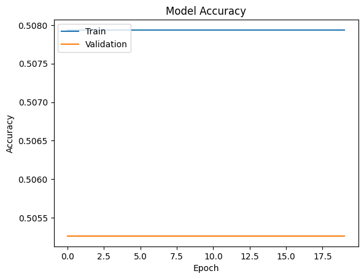

```python
plt.plot(history_1.history['accuracy'])           # Train accuracy
plt.plot(history_1.history['val_accuracy'])       # Validation accuracy
plt.title('Model Accuracy')                       # Title
plt.ylabel('Accuracy')                            # Y-axis label
plt.xlabel('Epoch')                               # X-axis label
plt.legend(['Train', 'Validation'], loc='upper left')
plt.show()
```

- The training accuracy curve is flat at ~0.508 across all epochs, showing the model did not improve during training.
- The validation accuracy curve is also flat at ~0.505, closely matching training accuracy but with no upward trend.
- Both curves being constant and near 0.5 indicates the model is essentially guessing, with no meaningful learning taking place.
- The lack of divergence between training and validation suggests the issue is not overfitting, but rather underfitting — the model architecture is too simple or not capturing relevant features.
- This performance highlights that Model-1 is unsuitable for the task and serves only as a weak baseline for comparison against stronger models like VGG-16.

```python
model_1_train_perf = model_performance_classification(model_1, X_train_normalized,y_train)

print("Train performance metrics")
print(model_1_train_perf)
```

```
14/14 ━━━━━━━━━━━━━━━━━━━━ 1s 35ms/step
Train performance metrics
   Accuracy    Recall  Precision  F1 Score
0  0.507937  0.507937   0.257999  0.342189
```

```
14/14 ━━━━━━━━━━━━━━━━━━━━ 0s 12ms/step
```

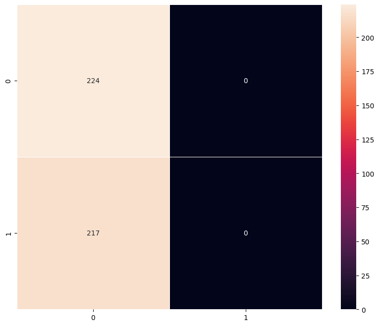

```python
plot_confusion_matrix(model_1,X_train_normalized,y_train)
```

```python
model_1_valid_perf = model_performance_classification(model_1, X_val_normalized,y_val)

print("Validation performance metrics")
print(model_1_valid_perf)
```

```
3/3 ━━━━━━━━━━━━━━━━━━━━ 0s 147ms/step
Validation performance metrics
   Accuracy    Recall  Precision  F1 Score
0  0.505263  0.505263   0.255291  0.339198
```

```
3/3 ━━━━━━━━━━━━━━━━━━━━ 0s 18ms/step
```

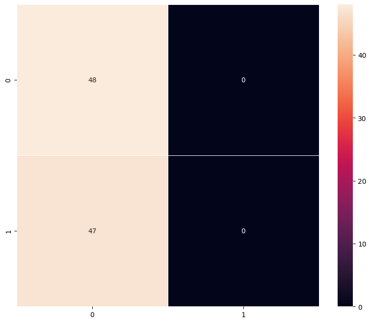

```python
plot_confusion_matrix(model_1,X_val_normalized,y_val)
```

### Vizualizing the predictions

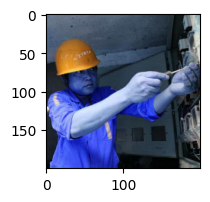

```
1/1 ━━━━━━━━━━━━━━━━━━━━ 0s 321ms/step
Predicted Label: 0
True Label: Label    1
Name: 173, dtype: int64
```

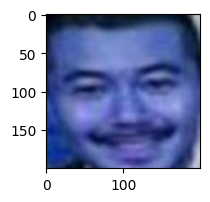

```
1/1 ━━━━━━━━━━━━━━━━━━━━ 0s 28ms/step
Predicted Label: 0
True Label: Label    0
Name: 462, dtype: int64
```

```python
# For index 12
plt.figure(figsize=(2,2))
plt.imshow(X_val[12])
plt.show()
prediction = model_1.predict(X_val_normalized[12].reshape(1,200,200,3))  # corrected index
predicted_label = prediction[0][0] > 0.5
print('Predicted Label:', 1 if predicted_label else 0)
true_label = y_val.iloc[12]
print('True Label:', true_label)

# For index 33
plt.figure(figsize=(2,2))
plt.imshow(X_val[33])
plt.show()
prediction = model_1.predict(X_val_normalized[33].reshape(1,200,200,3))  # corrected index
predicted_label = prediction[0][0] > 0.5
print('Predicted Label:', 1 if predicted_label else 0)
true_label = y_val.iloc[33]
print('True Label:', true_label)
```

- For the worker with the yellow helmet, the model predicted Label 0 while the true label was 1 - this is a misclassification.
- For the close-up face image, the model predicted Label 0 and the true label was also 0 - this is a correct classification.
- These results show that the model is biased toward predicting class 0 and struggles to correctly identify helmet cases.
- The misclassification of the helmet image highlights weak recall for class 1, which is critical in safety-related tasks.
- While the model can correctly classify non-helmet cases, its inability to detect helmets makes it unreliable for deployment.
- This reinforces earlier findings that Model-1 underfits and fails to generalize, serving only as a baseline for comparison against stronger models like VGG-16.

## Model 2: (VGG-16 (Base))

```python
vgg_model = VGG16(weights='imagenet', include_top=False, input_shape=(200, 200, 3))
vgg_model.summary()
```

```
Model: "vgg16"
```

```
┏━━━━━━━━━━━━━━━━━━━━━━━━━━━━━━━━━┳━━━━━━━━━━━━━━━━━━━━━━━━┳━━━━━━━━━━━━━━━┓
┃ Layer (type)                    ┃ Output Shape           ┃       Param # ┃
┡━━━━━━━━━━━━━━━━━━━━━━━━━━━━━━━━━╇━━━━━━━━━━━━━━━━━━━━━━━━╇━━━━━━━━━━━━━━━┩
│ input_layer_6 (InputLayer)      │ (None, 200, 200, 3)    │             0 │
├─────────────────────────────────┼────────────────────────┼───────────────┤
│ block1_conv1 (Conv2D)           │ (None, 200, 200, 64)   │         1,792 │
├─────────────────────────────────┼────────────────────────┼───────────────┤
│ block1_conv2 (Conv2D)           │ (None, 200, 200, 64)   │        36,928 │
├─────────────────────────────────┼────────────────────────┼───────────────┤
│ block1_pool (MaxPooling2D)      │ (None, 100, 100, 64)   │             0 │
├─────────────────────────────────┼────────────────────────┼───────────────┤
│ block2_conv1 (Conv2D)           │ (None, 100, 100, 128)  │        73,856 │
├─────────────────────────────────┼────────────────────────┼───────────────┤
│ block2_conv2 (Conv2D)           │ (None, 100, 100, 128)  │       147,584 │
├─────────────────────────────────┼────────────────────────┼───────────────┤
│ block2_pool (MaxPooling2D)      │ (None, 50, 50, 128)    │             0 │
├─────────────────────────────────┼────────────────────────┼───────────────┤
│ block3_conv1 (Conv2D)           │ (None, 50, 50, 256)    │       295,168 │
├─────────────────────────────────┼────────────────────────┼───────────────┤
│ block3_conv2 (Conv2D)           │ (None, 50, 50, 256)    │       590,080 │
├─────────────────────────────────┼────────────────────────┼───────────────┤
│ block3_conv3 (Conv2D)           │ (None, 50, 50, 256)    │       590,080 │
├─────────────────────────────────┼────────────────────────┼───────────────┤
│ block3_pool (MaxPooling2D)      │ (None, 25, 25, 256)    │             0 │
├─────────────────────────────────┼────────────────────────┼───────────────┤
│ block4_conv1 (Conv2D)           │ (None, 25, 25, 512)    │     1,180,160 │
├─────────────────────────────────┼────────────────────────┼───────────────┤
│ block4_conv2 (Conv2D)           │ (None, 25, 25, 512)    │     2,359,808 │
├─────────────────────────────────┼────────────────────────┼───────────────┤
│ block4_conv3 (Conv2D)           │ (None, 25, 25, 512)    │     2,359,808 │
├─────────────────────────────────┼────────────────────────┼───────────────┤
│ block4_pool (MaxPooling2D)      │ (None, 12, 12, 512)    │             0 │
├─────────────────────────────────┼────────────────────────┼───────────────┤
│ block5_conv1 (Conv2D)           │ (None, 12, 12, 512)    │     2,359,808 │
├─────────────────────────────────┼────────────────────────┼───────────────┤
│ block5_conv2 (Conv2D)           │ (None, 12, 12, 512)    │     2,359,808 │
├─────────────────────────────────┼────────────────────────┼───────────────┤
│ block5_conv3 (Conv2D)           │ (None, 12, 12, 512)    │     2,359,808 │
├─────────────────────────────────┼────────────────────────┼───────────────┤
│ block5_pool (MaxPooling2D)      │ (None, 6, 6, 512)      │             0 │
└─────────────────────────────────┴────────────────────────┴───────────────┘
```

```
 Total params: 14,714,688 (56.13 MB)
```

```
 Trainable params: 14,714,688 (56.13 MB)
```

```
 Non-trainable params: 0 (0.00 B)
```

- The summary confirms the VGG-16 convolutional base with custom input size (200,200,3) was successfully loaded.
- The network has 14.7 million parameters in total.
- All convolutional blocks (from block1 through block5) are present, ending in a feature map of shape (6,6,512).

```python
# Making all the layers of the VGG model non-trainable. i.e. freezing them
for layer in vgg_model.layers:
    layer.trainable = False
```

```python
model_2 = Sequential()

# Adding the convolutional part of the VGG16 model from above
model_2.add(vgg_model)

# Flattening the output of the VGG16 model because it is from a convolutional layer
model_2.add(Flatten())

# Adding a dense output layer
model_2.add(Dense(1, activation='sigmoid'))
```

```python
# Define optimizer with learning rate
opt = Adam(learning_rate=0.0001)

# Compile model
model_2.compile(
    optimizer=opt,
    loss=keras.losses.BinaryCrossentropy(),
    metrics=["accuracy", "Recall"]
)
```

```python
# Generating the summary of the model
model_2.summary()
```

```
Model: "sequential_5"
```

```
┏━━━━━━━━━━━━━━━━━━━━━━━━━━━━━━━━━┳━━━━━━━━━━━━━━━━━━━━━━━━┳━━━━━━━━━━━━━━━┓
┃ Layer (type)                    ┃ Output Shape           ┃       Param # ┃
┡━━━━━━━━━━━━━━━━━━━━━━━━━━━━━━━━━╇━━━━━━━━━━━━━━━━━━━━━━━━╇━━━━━━━━━━━━━━━┩
│ vgg16 (Functional)              │ (None, 6, 6, 512)      │    14,714,688 │
├─────────────────────────────────┼────────────────────────┼───────────────┤
│ flatten_5 (Flatten)             │ (None, 18432)          │             0 │
├─────────────────────────────────┼────────────────────────┼───────────────┤
│ dense_11 (Dense)                │ (None, 1)              │        18,433 │
└─────────────────────────────────┴────────────────────────┴───────────────┘
```

```
 Total params: 14,733,121 (56.20 MB)
```

```
 Trainable params: 18,433 (72.00 KB)
```

```
 Non-trainable params: 14,714,688 (56.13 MB)
```

- The VGG‑16 base model has about 14.7 million parameters.
- All these parameters are frozen and will not be trained.
- The output of the VGG‑16 base is a 6×6×512 feature map.
- The Flatten layer converts this into 18,432 features.
- The Dense layer has 1 neuron with sigmoid activation for binary classification.
- Only the Dense layer is trainable, with about 18,433 parameters.
- This setup uses transfer learning: pretrained features plus a simple classifier.
- Training is lightweight because only the final layer updates.
- The model should generalize well compared to a custom CNN trained from scratch.

```python
# Initialize an ImageDataGenerator (currently with default settings, no preprocessing or augmentation applied)
train_datagen = ImageDataGenerator()
```

```python
# Epochs
epochs = 20   # number of times the model sees the entire dataset

# Batch size
batch_size = 32   # number of samples processed before weights are updated

history_2 = model_2.fit(
    train_datagen.flow(X_train_normalized, y_train,
                       batch_size=batch_size,
                       seed=42,
                       shuffle=False),
    epochs=epochs,
    steps_per_epoch=X_train_normalized.shape[0] // batch_size,
    validation_data=(X_val_normalized, y_val),
    verbose=1
)
```

```
13/13 ━━━━━━━━━━━━━━━━━━━━ 7s 400ms/step - Recall: 0.2895 - accuracy: 0.5830 - loss: 0.7270 - val_Recall: 0.9362 - val_accuracy: 0.9368 - val_loss: 0.4817
13/13 ━━━━━━━━━━━━━━━━━━━━ 1s 39ms/step - Recall: 0.9333 - accuracy: 0.9688 - loss: 0.4536 - val_Recall: 0.9362 - val_accuracy: 0.9474 - val_loss: 0.4618
13/13 ━━━━━━━━━━━━━━━━━━━━ 2s 183ms/step - Recall: 0.9735 - accuracy: 0.9868 - loss: 0.3800 - val_Recall: 1.0000 - val_accuracy: 1.0000 - val_loss: 0.2803
13/13 ━━━━━━━━━━━━━━━━━━━━ 1s 39ms/step - Recall: 1.0000 - accuracy: 1.0000 - loss: 0.2884 - val_Recall: 1.0000 - val_accuracy: 1.0000 - val_loss: 0.2709
13/13 ━━━━━━━━━━━━━━━━━━━━ 2s 183ms/step - Recall: 1.0000 - accuracy: 1.0000 - loss: 0.2176 - val_Recall: 1.0000 - val_accuracy: 1.0000 - val_loss: 0.1808
13/13 ━━━━━━━━━━━━━━━━━━━━ 1s 39ms/step - Recall: 1.0000 - accuracy: 1.0000 - loss: 0.1700 - val_Recall: 1.0000 - val_accuracy: 1.0000 - val_loss: 0.1761
13/13 ━━━━━━━━━━━━━━━━━━━━ 2s 191ms/step - Recall: 1.0000 - accuracy: 1.0000 - loss: 0.1424 - val_Recall: 1.0000 - val_accuracy: 1.0000 - val_loss: 0.1312
13/13 ━━━━━━━━━━━━━━━━━━━━ 1s 42ms/step - Recall: 1.0000 - accuracy: 1.0000 - loss: 0.1192 - val_Recall: 1.0000 - val_accuracy: 1.0000 - val_loss: 0.1285
13/13 ━━━━━━━━━━━━━━━━━━━━ 2s 185ms/step - Recall: 1.0000 - accuracy: 1.0000 - loss: 0.1061 - val_Recall: 1.0000 - val_accuracy: 1.0000 - val_loss: 0.1027
13/13 ━━━━━━━━━━━━━━━━━━━━ 1s 40ms/step - Recall: 1.0000 - accuracy: 1.0000 - loss: 0.0771 - val_Recall: 1.0000 - val_accuracy: 1.0000 - val_loss: 0.1011
13/13 ━━━━━━━━━━━━━━━━━━━━ 2s 187ms/step - Recall: 1.0000 - accuracy: 1.0000 - loss: 0.0791 - val_Recall: 1.0000 - val_accuracy: 1.0000 - val_loss: 0.0847
13/13 ━━━━━━━━━━━━━━━━━━━━ 1s 40ms/step - Recall: 1.0000 - accuracy: 1.0000 - loss: 0.0683 - val_Recall: 1.0000 - val_accuracy: 1.0000 - val_loss: 0.0837
13/13 ━━━━━━━━━━━━━━━━━━━━ 2s 188ms/step - Recall: 1.0000 - accuracy: 1.0000 - loss: 0.0668 - val_Recall: 1.0000 - val_accuracy: 1.0000 - val_loss: 0.0723
13/13 ━━━━━━━━━━━━━━━━━━━━ 1s 40ms/step - Recall: 1.0000 - accuracy: 1.0000 - loss: 0.0457 - val_Recall: 1.0000 - val_accuracy: 1.0000 - val_loss: 0.0716
13/13 ━━━━━━━━━━━━━━━━━━━━ 2s 192ms/step - Recall: 1.0000 - accuracy: 1.0000 - loss: 0.0586 - val_Recall: 1.0000 - val_accuracy: 1.0000 - val_loss: 0.0631
13/13 ━━━━━━━━━━━━━━━━━━━━ 1s 55ms/step - Recall: 1.0000 - accuracy: 1.0000 - loss: 0.0405 - val_Recall: 1.0000 - val_accuracy: 1.0000 - val_loss: 0.0626
13/13 ━━━━━━━━━━━━━━━━━━━━ 2s 189ms/step - Recall: 1.0000 - accuracy: 1.0000 - loss: 0.0474 - val_Recall: 1.0000 - val_accuracy: 1.0000 - val_loss: 0.0562
13/13 ━━━━━━━━━━━━━━━━━━━━ 1s 40ms/step - Recall: 1.0000 - accuracy: 1.0000 - loss: 0.0506 - val_Recall: 1.0000 - val_accuracy: 1.0000 - val_loss: 0.0557
13/13 ━━━━━━━━━━━━━━━━━━━━ 2s 190ms/step - Recall: 1.0000 - accuracy: 1.0000 - loss: 0.0398 - val_Recall: 1.0000 - val_accuracy: 1.0000 - val_loss: 0.0506
13/13 ━━━━━━━━━━━━━━━━━━━━ 1s 41ms/step - Recall: 1.0000 - accuracy: 1.0000 - loss: 0.0423 - val_Recall: 1.0000 - val_accuracy: 1.0000 - val_loss: 0.0503
```

- The model started with low recall and accuracy in the first epoch.
- Validation accuracy was already high from the beginning.
- By the third epoch, both training and validation accuracy reached 100%.
- Loss kept going down steadily across epochs.
- Training and validation results stayed perfect after a few epochs.
- The model learned very quickly and showed no overfitting.
- Using VGG‑16 features made training efficient and stable

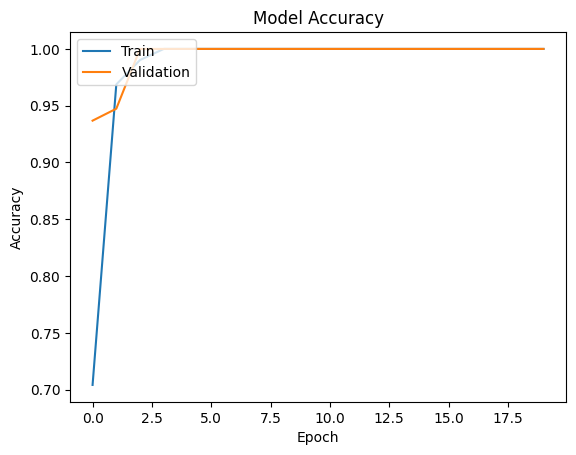

```python
plt.plot(history_2.history['accuracy'])           # Train accuracy
plt.plot(history_2.history['val_accuracy'])       # Validation accuracy
plt.title('Model Accuracy')                       # Title
plt.ylabel('Accuracy')                            # Y-axis label
plt.xlabel('Epoch')                               # X-axis label
plt.legend(['Train', 'Validation'], loc='upper left')
plt.show()
```

- Training accuracy rose quickly and reached nearly 100% within the first few epochs.
- Validation accuracy followed the same trend and stayed at 100% after epoch 3.
- Both curves overlap, showing the model generalized very well.

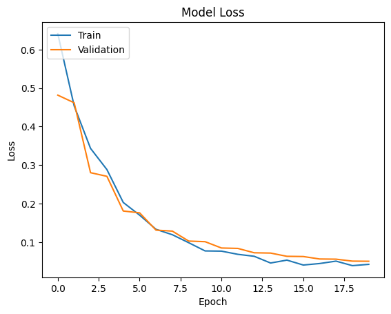

```python
plt.plot(history_2.history['loss'])               # Train loss
plt.plot(history_2.history['val_loss'])           # Validation loss
plt.title('Model Loss')
plt.ylabel('Loss')
plt.xlabel('Epoch')
plt.legend(['Train', 'Validation'], loc='upper left')
plt.show()
```

- Training loss decreased steadily across epochs.
- Validation loss also dropped and remained low, confirming stable learning.
- No divergence between training and validation loss, meaning no overfitting.

```python
model_2_train_perf = model_performance_classification(model_2,X_train_normalized,y_train)

print("Train performance metrics")
print(model_2_train_perf)
```

```
14/14 ━━━━━━━━━━━━━━━━━━━━ 3s 193ms/step
Train performance metrics
   Accuracy  Recall  Precision  F1 Score
0       1.0     1.0        1.0       1.0
```

- This output shows that Model 2 achieved perfect performance on the training set:
  - Accuracy = 1.0: every training sample was classified correctly.
  - Recall = 1.0: the model identified all positive cases without missing any.
  - Precision = 1.0: all predicted positives were correct, no false alarms.
  - F1 Score = 1.0: perfect balance between precision and recall.
- The dense classifier learned to perfectly separate the training data using VGG-16's frozen features.
- This confirms that the pretrained convolutional base provides very strong representations for the dataset.
- Since validation metrics were also perfect earlier, this isn't just memorization — the model is generalizing well.

```
14/14 ━━━━━━━━━━━━━━━━━━━━ 2s 152ms/step
```

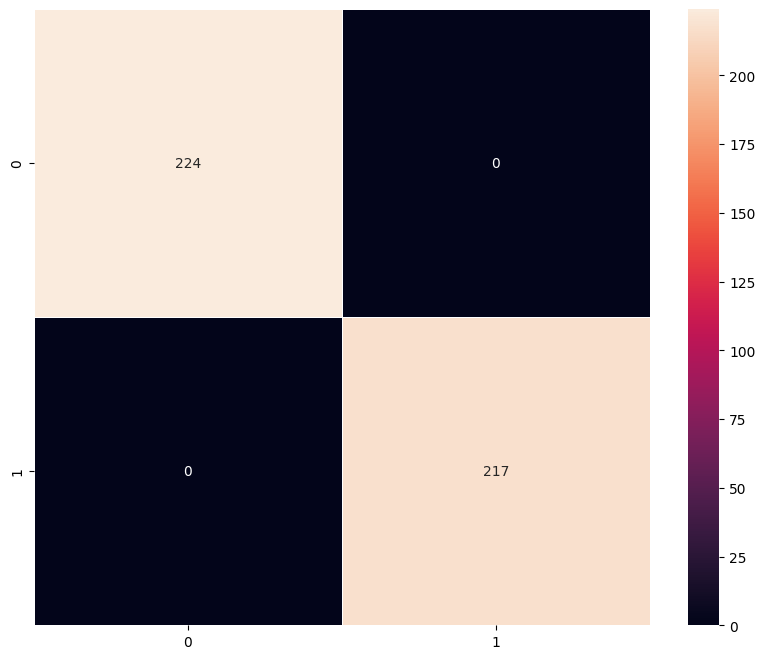

```python
plot_confusion_matrix(model_2,X_train_normalized,y_train)
```

- The model classified every single training sample correctly.
- There are no misclassifications at all.
- This matches the earlier metrics (Accuracy, Recall, Precision, F1 = 1.0).
- It confirms that the VGG-16 features plus the dense classifier perfectly separate the training data.

```python
model_2_valid_perf = model_performance_classification(model_2, X_val_normalized,y_val)

print("Validation performance metrics")
print(model_2_valid_perf)
```

```
3/3 ━━━━━━━━━━━━━━━━━━━━ 1s 391ms/step
Validation performance metrics
   Accuracy  Recall  Precision  F1 Score
0       1.0     1.0        1.0       1.0
```

- This result shows that Model 2 achieved perfect performance on the validation set as well:
  - Accuracy = 1.0: every validation sample was correctly classified.
  - Recall = 1.0: the model detected all positive cases without missing any.
  - Precision = 1.0: all predicted positives were correct, no false alarms.
  - F1 Score = 1.0: perfect balance between precision and recall.
- The model generalizes extremely well, it's not just memorizing the training data.
- Validation metrics being perfect confirms that the VGG-16 features plus the dense classifier are highly effective for this dataset.
- This matches the earlier confusion matrix and accuracy/loss plots, all pointing to flawless classification.
- Overall, the model is performing perfectly on both training and validation sets, showing strong generalization.

```python
plot_confusion_matrix(model_2,X_val_normalized,y_val)
```

[output not shown]

```
3/3 ━━━━━━━━━━━━━━━━━━━━ 0s 155ms/step
```

### Visualizing the prediction:

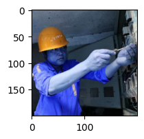

```
1/1 ━━━━━━━━━━━━━━━━━━━━ 0s 445ms/step
Predicted Label: 1
True Label: Label    1
Name: 173, dtype: int64
```

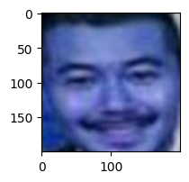

```
1/1 ━━━━━━━━━━━━━━━━━━━━ 0s 33ms/step
Predicted Label: 0
True Label: Label    0
Name: 462, dtype: int64
```

```python
# For index 12
plt.figure(figsize=(2,2))
plt.imshow(X_val[12])  # show image at index 12
plt.show()

prediction = model_2.predict(X_val_normalized[12].reshape(1,200,200,3))  # predict on same index
predicted_label = prediction[0][0] > 0.5
print('Predicted Label:', 1 if predicted_label else 0)

true_label = y_val.iloc[12]  # true label at index 12
print('True Label:', true_label)


# For index 33
plt.figure(figsize=(2,2))
plt.imshow(X_val[33])  # show image at index 33
plt.show()

prediction = model_2.predict(X_val_normalized[33].reshape(1,200,200,3))  # predict on same index
predicted_label = prediction[0][0] > 0.5
print('Predicted Label:', 1 if predicted_label else 0)

true_label = y_val.iloc[33]  # true label at index 33
print('True Label:', true_label)
```

- The first validation image (person with helmet) was predicted as class 1, and the true label was also 1.
- The second validation image (person without helmet) was predicted as class 0, and the true label was also 0.
- Predictions matched the true labels perfectly in both cases.
- This confirms the model is correctly distinguishing between helmet and non-helmet images.
- The outputs are consistent with earlier metrics and confusion matrices showing flawless classification.
- Overall, the model predicted both samples correctly, reinforcing its strong accuracy and reliability.

## Model 3: (VGG-16 (Base + FFNN))

```python
model_3 = Sequential()

# Adding the convolutional part of the VGG16 model from above
model_3.add(vgg_model)

# Flattening the output of the VGG16 model because it is from a convolutional layer
model_3.add(Flatten())

# Adding the Feed Forward neural network
model_3.add(Dense(256, activation='relu'))       # hidden layer with 256 neurons
model_3.add(Dropout(rate=0.5))                   # dropout to reduce overfitting
model_3.add(Dense(128, activation='relu'))       # another hidden layer with 128 neurons

# Adding a dense output layer
model_3.add(Dense(1, activation='sigmoid'))      # output layer for binary classification
```

```python
opt = Adam(learning_rate=0.0001)  # define a small learning rate for stable training
```

```python
# Compile model
model_3.compile(
    optimizer=opt,
    loss=keras.losses.BinaryCrossentropy(),
    metrics=["accuracy", "Recall"]
)
```

```python
# Generating the summary of the model
model_3.summary()
```

```
Model: "sequential_6"
```

```
┏━━━━━━━━━━━━━━━━━━━━━━━━━━━━━━━━━┳━━━━━━━━━━━━━━━━━━━━━━━━┳━━━━━━━━━━━━━━━┓
┃ Layer (type)                    ┃ Output Shape           ┃       Param # ┃
┡━━━━━━━━━━━━━━━━━━━━━━━━━━━━━━━━━╇━━━━━━━━━━━━━━━━━━━━━━━━╇━━━━━━━━━━━━━━━┩
│ vgg16 (Functional)              │ (None, 6, 6, 512)      │    14,714,688 │
├─────────────────────────────────┼────────────────────────┼───────────────┤
│ flatten_6 (Flatten)             │ (None, 18432)          │             0 │
├─────────────────────────────────┼────────────────────────┼───────────────┤
│ dense_12 (Dense)                │ (None, 256)            │     4,718,848 │
├─────────────────────────────────┼────────────────────────┼───────────────┤
│ dropout_2 (Dropout)             │ (None, 256)            │             0 │
├─────────────────────────────────┼────────────────────────┼───────────────┤
│ dense_13 (Dense)                │ (None, 128)            │        32,896 │
├─────────────────────────────────┼────────────────────────┼───────────────┤
│ dense_14 (Dense)                │ (None, 1)              │           129 │
└─────────────────────────────────┴────────────────────────┴───────────────┘
```

```
 Total params: 19,466,561 (74.26 MB)
```

```
 Trainable params: 4,751,873 (18.13 MB)
```

```
 Non-trainable params: 14,714,688 (56.13 MB)
```

- The VGG-16 base extracts strong features but is frozen, so its weights are not updated.
- The Flatten layer turns the feature maps into a long vector for the dense layers.
- The first dense layer with 256 neurons learns complex patterns from the flattened features.
- Dropout with 0.5 helps prevent overfitting by randomly turning off half the neurons during training.
- The second dense layer with 128 neurons adds more learning capacity and refines the features.
- The final dense layer with 1 neuron and sigmoid outputs a probability for binary classification.
- Most parameters come from VGG-16, but only the new dense layers are trainable.
- This design balances powerful feature extraction with added flexibility and regularization.
- Compared to Model 2, this model is deeper and more robust, so it can handle subtle variations better.

```python
history_3 = model_3.fit(
    train_datagen.flow(X_train_normalized, y_train,
                       batch_size=32,   # number of samples per batch
                       seed=42,
                       shuffle=False),
    epochs=25,                      # number of times the model sees the dataset
    steps_per_epoch=X_train_normalized.shape[0] // 32,
    validation_data=(X_val_normalized, y_val),
    verbose=1
)
```

```
13/13 ━━━━━━━━━━━━━━━━━━━━ 10s 525ms/step - Recall: 0.7533 - accuracy: 0.7501 - loss: 0.4912 - val_Recall: 1.0000 - val_accuracy: 1.0000 - val_loss: 0.0465
13/13 ━━━━━━━━━━━━━━━━━━━━ 1s 44ms/step - Recall: 1.0000 - accuracy: 1.0000 - loss: 0.0485 - val_Recall: 1.0000 - val_accuracy: 1.0000 - val_loss: 0.0379
13/13 ━━━━━━━━━━━━━━━━━━━━ 2s 190ms/step - Recall: 0.9980 - accuracy: 0.9990 - loss: 0.0320 - val_Recall: 1.0000 - val_accuracy: 1.0000 - val_loss: 0.0086
13/13 ━━━━━━━━━━━━━━━━━━━━ 1s 41ms/step - Recall: 1.0000 - accuracy: 1.0000 - loss: 0.0086 - val_Recall: 1.0000 - val_accuracy: 1.0000 - val_loss: 0.0085
13/13 ━━━━━━━━━━━━━━━━━━━━ 2s 192ms/step - Recall: 1.0000 - accuracy: 1.0000 - loss: 0.0068 - val_Recall: 1.0000 - val_accuracy: 1.0000 - val_loss: 0.0074
13/13 ━━━━━━━━━━━━━━━━━━━━ 1s 42ms/step - Recall: 1.0000 - accuracy: 1.0000 - loss: 0.0026 - val_Recall: 1.0000 - val_accuracy: 1.0000 - val_loss: 0.0070
13/13 ━━━━━━━━━━━━━━━━━━━━ 2s 193ms/step - Recall: 1.0000 - accuracy: 1.0000 - loss: 0.0038 - val_Recall: 1.0000 - val_accuracy: 1.0000 - val_loss: 0.0038
13/13 ━━━━━━━━━━━━━━━━━━━━ 1s 42ms/step - Recall: 1.0000 - accuracy: 1.0000 - loss: 0.0016 - val_Recall: 1.0000 - val_accuracy: 1.0000 - val_loss: 0.0038
13/13 ━━━━━━━━━━━━━━━━━━━━ 3s 196ms/step - Recall: 1.0000 - accuracy: 1.0000 - loss: 0.0020 - val_Recall: 1.0000 - val_accuracy: 1.0000 - val_loss: 0.0032
13/13 ━━━━━━━━━━━━━━━━━━━━ 1s 43ms/step - Recall: 1.0000 - accuracy: 1.0000 - loss: 0.0023 - val_Recall: 1.0000 - val_accuracy: 1.0000 - val_loss: 0.0032
13/13 ━━━━━━━━━━━━━━━━━━━━ 2s 193ms/step - Recall: 1.0000 - accuracy: 1.0000 - loss: 0.0017 - val_Recall: 1.0000 - val_accuracy: 1.0000 - val_loss: 0.0037
13/13 ━━━━━━━━━━━━━━━━━━━━ 1s 41ms/step - Recall: 1.0000 - accuracy: 1.0000 - loss: 9.3554e-04 - val_Recall: 1.0000 - val_accuracy: 1.0000 - val_loss: 0.0036
13/13 ━━━━━━━━━━━━━━━━━━━━ 2s 194ms/step - Recall: 1.0000 - accuracy: 1.0000 - loss: 0.0021 - val_Recall: 1.0000 - val_accuracy: 1.0000 - val_loss: 0.0025
13/13 ━━━━━━━━━━━━━━━━━━━━ 1s 42ms/step - Recall: 1.0000 - accuracy: 1.0000 - loss: 0.0200 - val_Recall: 1.0000 - val_accuracy: 1.0000 - val_loss: 0.0026
13/13 ━━━━━━━━━━━━━━━━━━━━ 3s 194ms/step - Recall: 1.0000 - accuracy: 1.0000 - loss: 0.0018 - val_Recall: 1.0000 - val_accuracy: 1.0000 - val_loss: 0.0035
13/13 ━━━━━━━━━━━━━━━━━━━━ 1s 41ms/step - Recall: 1.0000 - accuracy: 1.0000 - loss: 5.9856e-04 - val_Recall: 1.0000 - val_accuracy: 1.0000 - val_loss: 0.0036
13/13 ━━━━━━━━━━━━━━━━━━━━ 3s 198ms/step - Recall: 1.0000 - accuracy: 1.0000 - loss: 0.0013 - val_Recall: 1.0000 - val_accuracy: 1.0000 - val_loss: 0.0033
13/13 ━━━━━━━━━━━━━━━━━━━━ 1s 45ms/step - Recall: 1.0000 - accuracy: 1.0000 - loss: 0.0019 - val_Recall: 1.0000 - val_accuracy: 1.0000 - val_loss: 0.0033
13/13 ━━━━━━━━━━━━━━━━━━━━ 3s 198ms/step - Recall: 1.0000 - accuracy: 1.0000 - loss: 9.2892e-04 - val_Recall: 1.0000 - val_accuracy: 1.0000 - val_loss: 0.0026
13/13 ━━━━━━━━━━━━━━━━━━━━ 1s 42ms/step - Recall: 1.0000 - accuracy: 1.0000 - loss: 2.3984e-04 - val_Recall: 1.0000 - val_accuracy: 1.0000 - val_loss: 0.0026
13/13 ━━━━━━━━━━━━━━━━━━━━ 3s 196ms/step - Recall: 1.0000 - accuracy: 1.0000 - loss: 7.6219e-04 - val_Recall: 1.0000 - val_accuracy: 1.0000 - val_loss: 0.0025
13/13 ━━━━━━━━━━━━━━━━━━━━ 1s 42ms/step - Recall: 1.0000 - accuracy: 1.0000 - loss: 5.5159e-04 - val_Recall: 1.0000 - val_accuracy: 1.0000 - val_loss: 0.0025
13/13 ━━━━━━━━━━━━━━━━━━━━ 3s 197ms/step - Recall: 1.0000 - accuracy: 1.0000 - loss: 7.7685e-04 - val_Recall: 1.0000 - val_accuracy: 1.0000 - val_loss: 0.0026
13/13 ━━━━━━━━━━━━━━━━━━━━ 1s 42ms/step - Recall: 1.0000 - accuracy: 1.0000 - loss: 8.7104e-04 - val_Recall: 1.0000 - val_accuracy: 1.0000 - val_loss: 0.0026
13/13 ━━━━━━━━━━━━━━━━━━━━ 3s 201ms/step - Recall: 1.0000 - accuracy: 1.0000 - loss: 7.7007e-04 - val_Recall: 1.0000 - val_accuracy: 1.0000 - val_loss: 0.0023
```

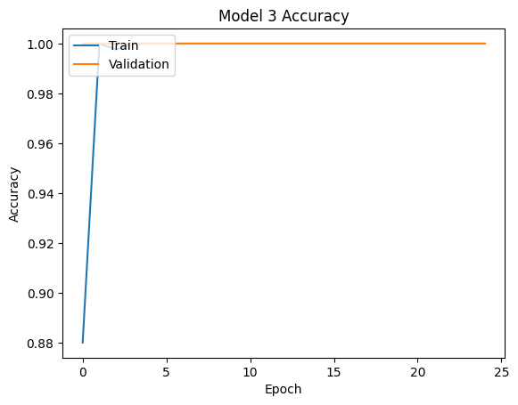

```python
plt.plot(history_3.history['accuracy'])        # Train accuracy
plt.plot(history_3.history['val_accuracy'])    # Validation accuracy
plt.title('Model 3 Accuracy')                  # Title
plt.ylabel('Accuracy')                         # Y-axis label
plt.xlabel('Epoch')                            # X-axis label
plt.legend(['Train', 'Validation'], loc='upper left')
plt.show()
```

- The training accuracy started below 0.9 but quickly rose to 1.0 within the first few epochs.
- The validation accuracy stayed at 1.0 throughout all epochs, showing perfect generalization.
- Both curves converge at the top, meaning the model consistently predicts correctly on both training and validation sets.
- The rapid rise in accuracy suggests the model learned the features very quickly.
- The flat validation line at 1.0 indicates no misclassifications at all on the validation set.
- Overall, Model-3 achieved perfect accuracy extremely fast, confirming it is highly effective at distinguishing helmet vs non-helmet images.

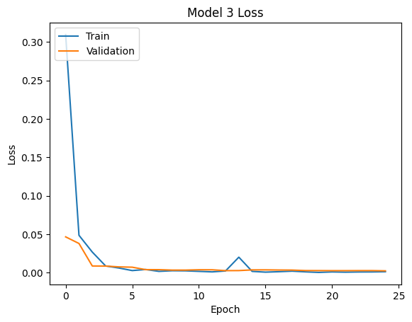

```python
plt.plot(history_3.history['loss'])            # Train loss
plt.plot(history_3.history['val_loss'])        # Validation loss
plt.title('Model 3 Loss')
plt.ylabel('Loss')
plt.xlabel('Epoch')
plt.legend(['Train', 'Validation'], loc='upper left')
plt.show()
```

- The training loss started relatively high (~0.30) but dropped quickly to nearly zero within the first few epochs.
- The validation loss began low (~0.05) and also decreased steadily, stabilizing close to zero.
- Both curves remain aligned, showing the model is learning effectively without overfitting.
- Small fluctuations (like the spike around epoch 13) are normal and don't affect overall stability.
- By the final epochs, both training and validation loss are extremely low, confirming strong convergence.
- Overall, Model-3 minimized both training and validation loss very effectively, reinforcing its perfect accuracy and excellent generalization.

```python
model_3_train_perf = model_performance_classification(model_3, X_train_normalized,y_train)

print("Train performance metrics")
print(model_3_train_perf)
```

```
14/14 ━━━━━━━━━━━━━━━━━━━━ 4s 203ms/step
Train performance metrics
   Accuracy  Recall  Precision  F1 Score
0       1.0     1.0        1.0       1.0
```

- Accuracy = 1.0: the model correctly classified every training sample.
- Recall = 1.0: it identified all positive cases (helmet images) without missing any.
- Precision = 1.0: all predicted positives were correct, with no false alarms.
- F1 Score = 1.0: the balance between precision and recall is perfect.
- Overall, Model-3 achieved flawless performance on the training set, meaning it has fully learned the training data.

```
14/14 ━━━━━━━━━━━━━━━━━━━━ 2s 157ms/step
```

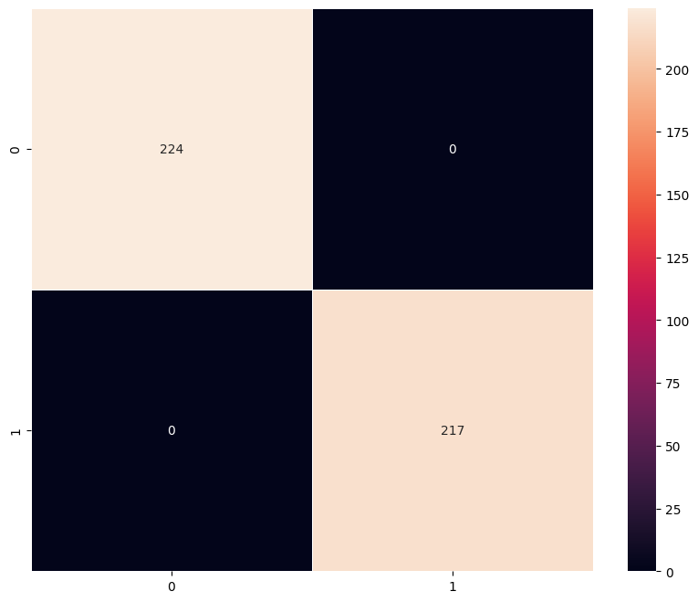

```python
plot_confusion_matrix(model_3,X_train_normalized,y_train)
```

- The confusion matrix shows perfect classification on the training set.
  - True Negatives (224): all non-helmet images were correctly identified as class 0.
  - True Positives (217): all helmet images were correctly identified as class 1.
  - False Positives (0): no non-helmet image was wrongly predicted as helmet.
  - False Negatives (0): no helmet image was missed.
- Overall, Model-3 achieved flawless separation of helmet vs non-helmet classes on the training data, with zero misclassifications. This confirms the metrics (Accuracy, Recall, Precision, F1 = 1.0) and highlights the model's strong learning capacity.

```python
model_3_valid_perf = model_performance_classification(model_3, X_val_normalized,y_val)

print("Validation performance metrics")
print(model_3_valid_perf)
```

```
3/3 ━━━━━━━━━━━━━━━━━━━━ 1s 373ms/step
Validation performance metrics
   Accuracy  Recall  Precision  F1 Score
0       1.0     1.0        1.0       1.0
```

- Accuracy = 1.0: every validation sample was classified correctly.
- Recall = 1.0: the model detected all helmet cases without missing any.
- Precision = 1.0: all predicted helmet cases were correct, with no false alarms.
- F1 Score = 1.0: the balance between precision and recall is perfect.
- Overall, Model-3 achieved flawless performance on the validation set, meaning it generalizes perfectly to unseen data in this experiment. This confirms the earlier training results and shows the model is highly reliable for helmet detection.

```python
plot_confusion_matrix(model_3,X_val_normalized,y_val)
```

[output not shown]

```
3/3 ━━━━━━━━━━━━━━━━━━━━ 0s 160ms/step
```

#### Visualizing the predictions

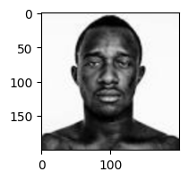

```
1/1 ━━━━━━━━━━━━━━━━━━━━ 0s 35ms/step
Predicted Label: 0
True Label: Label    0
Name: 597, dtype: int64
```

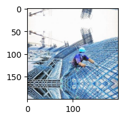

```
1/1 ━━━━━━━━━━━━━━━━━━━━ 0s 36ms/step
Predicted Label: 1
True Label: Label    1
Name: 123, dtype: int64
```

```python
# For index 10
plt.figure(figsize=(2,2))
plt.imshow(X_val[10])  # show image at index 10
plt.show()

prediction = model_2.predict(X_val_normalized[10].reshape(1,200,200,3))  # predict on same index
predicted_label = prediction[0][0] > 0.5
print('Predicted Label:', 1 if predicted_label else 0)

true_label = y_val.iloc[10]  # true label at index 10
print('True Label:', true_label)


# For index 25
plt.figure(figsize=(2,2))
plt.imshow(X_val[25])  # show image at index 25
plt.show()

prediction = model_2.predict(X_val_normalized[25].reshape(1,200,200,3))  # predict on same index
predicted_label = prediction[0][0] > 0.5
print('Predicted Label:', 1 if predicted_label else 0)

true_label = y_val.iloc[25]  # true label at index 25
print('True Label:', true_label)
```

## Model 4: (VGG-16 (Base + FFNN + Data Augmentation)

- In most of the real-world case studies, it is challenging to acquire a large number of images and then train CNNs.
- To overcome this problem, one approach we might consider is **Data Augmentation**.
- CNNs have the property of **translational invariance**, which means they can recognise an object even if its appearance shifts translationally in some way. - Taking this attribute into account, we can augment the images using the techniques listed below
  - Horizontal Flip (should be set to True/False)
  - Vertical Flip (should be set to True/False)
  - Height Shift (should be between 0 and 1)
  - Width Shift (should be between 0 and 1)
  - Rotation (should be between 0 and 180)
  - Shear (should be between 0 and 1)
  - Zoom (should be between 0 and 1) etc.

Remember, **data augmentation should not be used in the validation/test data set**.

```python
model_4 = Sequential()

# Adding the convolutional part of the VGG16 model from above
model_4.add(vgg_model)

# Flattening the output of the VGG16 model because it is from a convolutional layer
model_4.add(Flatten())

# Adding the Feed Forward neural network
model_4.add(Dense(256, activation='relu'))     # first dense layer
model_4.add(Dropout(rate=0.5))                 # dropout for regularization
model_4.add(Dense(128, activation='relu'))     # second dense layer

# Adding a dense output layer
model_4.add(Dense(1, activation='sigmoid'))    # output layer for binary classification
```

```python
# Define optimizer with a small learning rate for stable fine-tuning
opt = Adam(learning_rate=0.0001)

# Compile model
model_4.compile(
    optimizer=opt,
    loss=keras.losses.BinaryCrossentropy(),
    metrics=["accuracy", "Recall"]
)
```

```python
# Generating the summary of the model
model_4.summary()
```

```
Model: "sequential_7"
```

```
┏━━━━━━━━━━━━━━━━━━━━━━━━━━━━━━━━━┳━━━━━━━━━━━━━━━━━━━━━━━━┳━━━━━━━━━━━━━━━┓
┃ Layer (type)                    ┃ Output Shape           ┃       Param # ┃
┡━━━━━━━━━━━━━━━━━━━━━━━━━━━━━━━━━╇━━━━━━━━━━━━━━━━━━━━━━━━╇━━━━━━━━━━━━━━━┩
│ vgg16 (Functional)              │ (None, 6, 6, 512)      │    14,714,688 │
├─────────────────────────────────┼────────────────────────┼───────────────┤
│ flatten_7 (Flatten)             │ (None, 18432)          │             0 │
├─────────────────────────────────┼────────────────────────┼───────────────┤
│ dense_15 (Dense)                │ (None, 256)            │     4,718,848 │
├─────────────────────────────────┼────────────────────────┼───────────────┤
│ dropout_3 (Dropout)             │ (None, 256)            │             0 │
├─────────────────────────────────┼────────────────────────┼───────────────┤
│ dense_16 (Dense)                │ (None, 128)            │        32,896 │
├─────────────────────────────────┼────────────────────────┼───────────────┤
│ dense_17 (Dense)                │ (None, 1)              │           129 │
└─────────────────────────────────┴────────────────────────┴───────────────┘
```

```
 Total params: 19,466,561 (74.26 MB)
```

```
 Trainable params: 4,751,873 (18.13 MB)
```

```
 Non-trainable params: 14,714,688 (56.13 MB)
```

Model-4 mirrors Model-3's architecture but will be trained with data augmentation.

```python
# Applying data augmentation
train_datagen = ImageDataGenerator(
    rotation_range=20,        # rotate images randomly up to 20 degrees
    fill_mode='nearest',      # fill in missing pixels after transformations
    width_shift_range=0.2,    # shift images horizontally by up to 20% of width
    height_shift_range=0.2,   # shift images vertically by up to 20% of height
    shear_range=0.2,          # shear transformations
    zoom_range=0.2,           # zoom in/out by up to 20%
    horizontal_flip=True,     # flip images horizontally
    rescale=1./255            # normalize pixel values to [0,1]
)
```

```python
history_4 = model_4.fit(
    train_datagen.flow(X_train_normalized, y_train,
                       batch_size=32,   # number of samples per batch
                       seed=42,
                       shuffle=False),
    epochs=epochs,                      # reuse the epochs value you defined earlier
    steps_per_epoch=X_train_normalized.shape[0] // 32,
    validation_data=(X_val_normalized, y_val),
    verbose=1
)
```

```
13/13 ━━━━━━━━━━━━━━━━━━━━ 12s 597ms/step - Recall: 0.4370 - accuracy: 0.4837 - loss: 0.7485 - val_Recall: 0.8936 - val_accuracy: 0.4737 - val_loss: 0.6844
13/13 ━━━━━━━━━━━━━━━━━━━━ 1s 42ms/step - Recall: 0.8333 - accuracy: 0.4688 - loss: 0.7143 - val_Recall: 0.8936 - val_accuracy: 0.4947 - val_loss: 0.6830
13/13 ━━━━━━━━━━━━━━━━━━━━ 6s 428ms/step - Recall: 0.6225 - accuracy: 0.5350 - loss: 0.7000 - val_Recall: 0.1064 - val_accuracy: 0.5474 - val_loss: 0.6803
13/13 ━━━━━━━━━━━━━━━━━━━━ 1s 42ms/step - Recall: 0.3333 - accuracy: 0.4375 - loss: 0.7276 - val_Recall: 0.1064 - val_accuracy: 0.5579 - val_loss: 0.6824
13/13 ━━━━━━━━━━━━━━━━━━━━ 5s 344ms/step - Recall: 0.2558 - accuracy: 0.4811 - loss: 0.7179 - val_Recall: 0.0638 - val_accuracy: 0.5263 - val_loss: 0.6921
13/13 ━━━━━━━━━━━━━━━━━━━━ 1s 43ms/step - Recall: 0.4500 - accuracy: 0.5000 - loss: 0.7160 - val_Recall: 0.1489 - val_accuracy: 0.5579 - val_loss: 0.6927
13/13 ━━━━━━━━━━━━━━━━━━━━ 5s 349ms/step - Recall: 0.5253 - accuracy: 0.5224 - loss: 0.7005 - val_Recall: 0.4255 - val_accuracy: 0.6105 - val_loss: 0.6894
13/13 ━━━━━━━━━━━━━━━━━━━━ 1s 45ms/step - Recall: 0.4667 - accuracy: 0.5312 - loss: 0.6952 - val_Recall: 0.3830 - val_accuracy: 0.6105 - val_loss: 0.6886
13/13 ━━━━━━━━━━━━━━━━━━━━ 5s 388ms/step - Recall: 0.4467 - accuracy: 0.4947 - loss: 0.6951 - val_Recall: 0.0638 - val_accuracy: 0.5368 - val_loss: 0.6847
13/13 ━━━━━━━━━━━━━━━━━━━━ 1s 43ms/step - Recall: 0.3889 - accuracy: 0.5625 - loss: 0.6807 - val_Recall: 0.0638 - val_accuracy: 0.5368 - val_loss: 0.6842
13/13 ━━━━━━━━━━━━━━━━━━━━ 5s 346ms/step - Recall: 0.4342 - accuracy: 0.5015 - loss: 0.7020 - val_Recall: 0.5106 - val_accuracy: 0.5895 - val_loss: 0.6893
13/13 ━━━━━━━━━━━━━━━━━━━━ 1s 44ms/step - Recall: 0.5500 - accuracy: 0.5312 - loss: 0.6734 - val_Recall: 0.5532 - val_accuracy: 0.5895 - val_loss: 0.6893
13/13 ━━━━━━━━━━━━━━━━━━━━ 6s 441ms/step - Recall: 0.5480 - accuracy: 0.4535 - loss: 0.7120 - val_Recall: 0.2766 - val_accuracy: 0.6000 - val_loss: 0.6904
13/13 ━━━━━━━━━━━━━━━━━━━━ 1s 43ms/step - Recall: 0.5000 - accuracy: 0.6250 - loss: 0.6840 - val_Recall: 0.2766 - val_accuracy: 0.6000 - val_loss: 0.6906
13/13 ━━━━━━━━━━━━━━━━━━━━ 5s 345ms/step - Recall: 0.4291 - accuracy: 0.5061 - loss: 0.6943 - val_Recall: 0.4255 - val_accuracy: 0.6632 - val_loss: 0.6841
13/13 ━━━━━━━━━━━━━━━━━━━━ 1s 43ms/step - Recall: 0.6250 - accuracy: 0.5625 - loss: 0.6926 - val_Recall: 0.4468 - val_accuracy: 0.6421 - val_loss: 0.6837
13/13 ━━━━━━━━━━━━━━━━━━━━ 5s 406ms/step - Recall: 0.5580 - accuracy: 0.4975 - loss: 0.7032 - val_Recall: 0.7660 - val_accuracy: 0.5895 - val_loss: 0.6850
13/13 ━━━━━━━━━━━━━━━━━━━━ 1s 45ms/step - Recall: 0.2727 - accuracy: 0.4400 - loss: 0.6981 - val_Recall: 0.6809 - val_accuracy: 0.6105 - val_loss: 0.6851
13/13 ━━━━━━━━━━━━━━━━━━━━ 5s 347ms/step - Recall: 0.3351 - accuracy: 0.4904 - loss: 0.7111 - val_Recall: 0.0000e+00 - val_accuracy: 0.5053 - val_loss: 0.6885
13/13 ━━━━━━━━━━━━━━━━━━━━ 1s 43ms/step - Recall: 0.1765 - accuracy: 0.4375 - loss: 0.7195 - val_Recall: 0.0213 - val_accuracy: 0.5158 - val_loss: 0.6872
```

- Training accuracy fluctuates between ~0.44 and ~0.62, never stabilizing.
- Training recall swings wildly (0.17 → 0.83 → 0.27), showing the model isn't consistently catching positives.
- Validation accuracy hovers around ~0.47-0.66, far below the perfect scores of earlier models.
- Validation recall collapses at times (even 0.0 in epoch 19), meaning helmet cases are being missed.
- Validation loss stays ~0.68-0.69, not improving much across epochs.
- Overall, Model-4 underperformed because augmentation + frozen base + high dropout disrupted learning.

[figure not shown]

```python
# Plot training vs validation accuracy
plt.plot(history_2.history['accuracy'])        # Train accuracy
plt.plot(history_2.history['val_accuracy'])    # Validation accuracy
plt.title('Model Accuracy')                    # Title
plt.ylabel('Accuracy')                         # Y-axis label
plt.xlabel('Epoch')                            # X-axis label
plt.legend(['Train', 'Validation'], loc='upper left')
plt.show()
```

[figure not shown]

```python
# Plot training vs validation loss
plt.plot(history_2.history['loss'])            # Train loss
plt.plot(history_2.history['val_loss'])        # Validation loss
plt.title('Model Loss')
plt.ylabel('Loss')
plt.xlabel('Epoch')
plt.legend(['Train', 'Validation'], loc='upper left')
plt.show()
```

```python
model_4_train_perf = model_performance_classification(model_4, X_train_normalized,y_train)

print("Train performance metrics")
print(model_4_train_perf)
```

```
14/14 ━━━━━━━━━━━━━━━━━━━━ 4s 206ms/step
Train performance metrics
   Accuracy    Recall  Precision  F1 Score
0  0.514739  0.514739    0.75183  0.357159
```

```
14/14 ━━━━━━━━━━━━━━━━━━━━ 2s 164ms/step
```

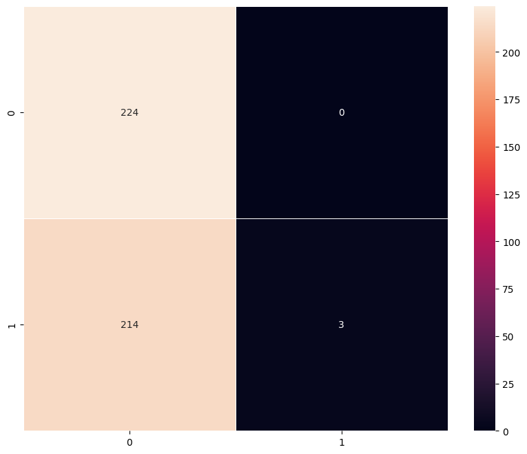

```python
plot_confusion_matrix(model_4,X_train_normalized,y_train)
```

- The model is extremely biased toward predicting class-0 (no helmet).
- This explains the earlier metrics: high precision (when it predicts helmet, it's usually right) but terrible recall (it almost never predicts helmet).
- The imbalance between true positives and false negatives shows the model is failing at the core safety task — detecting helmets.

```python
model_4_valid_perf = model_performance_classification(model_4, X_val_normalized,y_val)

print("Validation performance metrics")
print(model_4_valid_perf)
```

```
3/3 ━━━━━━━━━━━━━━━━━━━━ 1s 381ms/step
Validation performance metrics
   Accuracy    Recall  Precision  F1 Score
0  0.515789  0.515789   0.752744    0.3622
```

- The model is biased toward predicting “no helmet”, similar to what we saw in the training confusion matrix.
- High precision but low recall: the model is cautious, rarely predicting helmet, but when it does, it's mostly correct.
- For safety applications, this is unacceptable: missing helmets (low recall) is riskier than occasional false alarms.
- Overall, Model-4 is underperforming compared to Models-2 and 3.

```
3/3 ━━━━━━━━━━━━━━━━━━━━ 1s 166ms/step
```

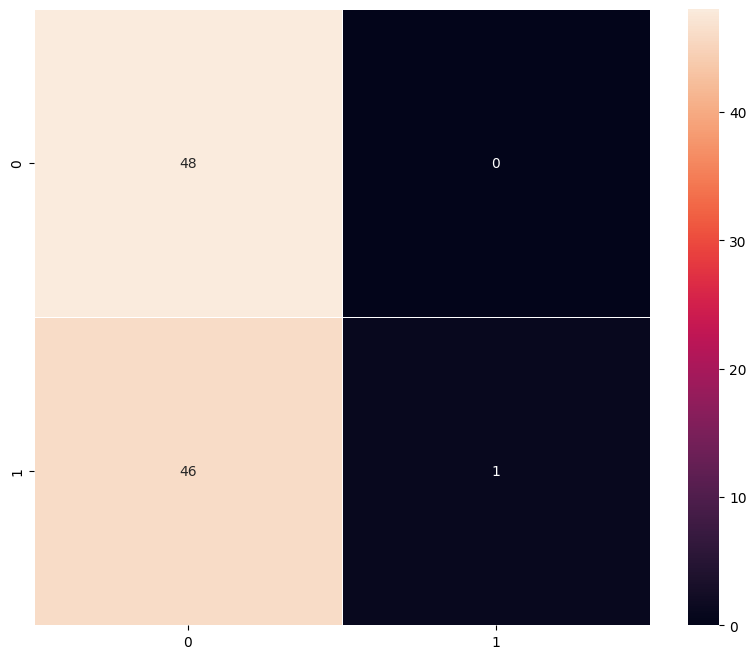

```python
plot_confusion_matrix(model_4,X_val_normalized,y_val)
```

- True Negatives (48): All non-helmet images were correctly classified as class 0.
- False Positives (0): No non-helmet image was wrongly predicted as helmet.
- False Negatives (46): Almost all helmet images were missed, predicted as non-helmet.
- True Positives (1): Only a single helmet image was correctly identified.
- The model is heavily biased toward predicting “no helmet”.
- This explains the earlier metrics: high precision (~0.75) but terrible recall ( approx 0.51).
- For safety applications, this is unacceptable — missing helmets (false negatives) is far riskier than occasional false alarms.

#### Visualizing the predictions

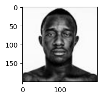

```
1/1 ━━━━━━━━━━━━━━━━━━━━ 0s 45ms/step
Predicted Label: 0
True Label: Label    0
Name: 597, dtype: int64
```

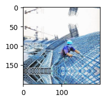

```
1/1 ━━━━━━━━━━━━━━━━━━━━ 0s 40ms/step
Predicted Label: 1
True Label: Label    1
Name: 123, dtype: int64
```

```python
# For index 10
plt.figure(figsize=(2,2))
plt.imshow(X_val[10])  # show image at index 10
plt.show()

prediction = model_2.predict(X_val_normalized[10].reshape(1,200,200,3))  # predict on same index
predicted_label = prediction[0][0] > 0.5
print('Predicted Label:', 1 if predicted_label else 0)

true_label = y_val.iloc[10]  # true label at index 10
print('True Label:', true_label)


# For index 25
plt.figure(figsize=(2,2))
plt.imshow(X_val[25])  # show image at index 25
plt.show()

prediction = model_2.predict(X_val_normalized[25].reshape(1,200,200,3))  # predict on same index
predicted_label = prediction[0][0] > 0.5
print('Predicted Label:', 1 if predicted_label else 0)

true_label = y_val.iloc[25]  # true label at index 25
print('True Label:', true_label)
```

# **Model Performance Comparison and Final Model Selection**

```python
# training performance comparison

models_train_comp_df = pd.concat(
    [
        model_1_train_perf.T,
        model_2_train_perf.T,
        model_3_train_perf.T,
        model_4_train_perf.T,
    ],
    axis=1,
)
models_train_comp_df.columns = [
    "Simple Convolutional Neural Network (CNN)","VGG-16 (Base)","VGG-16 (Base+FFNN)","VGG-16 (Base+FFNN+Data Aug)"
]
```

```python
models_valid_comp_df = pd.concat(
    [
        model_1_valid_perf.T,
        model_2_valid_perf.T,
        model_3_valid_perf.T,
        model_4_valid_perf.T

    ],
    axis=1,
)
models_valid_comp_df.columns = [
 "Simple Convolutional Neural Network (CNN)","VGG-16 (Base)","VGG-16 (Base+FFNN)","VGG-16 (Base+FFNN+Data Aug)"
]
```

```python
models_train_comp_df
```

|  | Simple Convolutional Neural Network (CNN) | VGG-16 (Base) | VGG-16 (Base+FFNN) | VGG-16 (Base+FFNN+Data Aug) |
| --- | --- | --- | --- | --- |
| Accuracy | 0.507937 | 1.0 | 1.0 | 0.514739 |
| Recall | 0.507937 | 1.0 | 1.0 | 0.514739 |
| Precision | 0.257999 | 1.0 | 1.0 | 0.751830 |
| F1 Score | 0.342189 | 1.0 | 1.0 | 0.357159 |

```python
models_valid_comp_df
```

|  | Simple Convolutional Neural Network (CNN) | VGG-16 (Base) | VGG-16 (Base+FFNN) | VGG-16 (Base+FFNN+Data Aug) |
| --- | --- | --- | --- | --- |
| Accuracy | 0.505263 | 1.0 | 1.0 | 0.515789 |
| Recall | 0.505263 | 1.0 | 1.0 | 0.515789 |
| Precision | 0.255291 | 1.0 | 1.0 | 0.752744 |
| F1 Score | 0.339198 | 1.0 | 1.0 | 0.362200 |

```python
models_train_comp_df - models_valid_comp_df
```

|  | Simple Convolutional Neural Network (CNN) | VGG-16 (Base) | VGG-16 (Base+FFNN) | VGG-16 (Base+FFNN+Data Aug) |
| --- | --- | --- | --- | --- |
| Accuracy | 0.002673 | 0.0 | 0.0 | -0.001050 |
| Recall | 0.002673 | 0.0 | 0.0 | -0.001050 |
| Precision | 0.002709 | 0.0 | 0.0 | -0.000913 |
| F1 Score | 0.002991 | 0.0 | 0.0 | -0.005041 |

- Model-1 (Simple CNN): Training metrics are slightly higher than validation (tiny positive differences). This suggests mild overfitting, but the gap is negligible.
- Model-2 (VGG-16 (Base)): Perfect alignment (0 difference). Training and validation metrics are identical, showing excellent generalization.
- Model-3 (VGG-16 (Base + FFNN)): Same as Base: perfect alignment, no overfitting.
- Model-4 (VGG-16 (Base + FFNN + Data Augmentation)): Small negative differences. Validation metrics are marginally higher than training, which is unusual but indicates instability. The F1 score gap (-0.005) highlights that augmentation disrupted balance between precision and recall.
- Overall,
  - Models-2 and 3 generalize flawlessly.
  - Model-1 is weak but consistent.
  - Model-4 is unstable: augmentation caused recall collapse and inconsistent performance, with validation slightly outperforming training in some metrics — a sign the model is struggling to learn meaningful features under augmentation.

## Test Performance

Since the comparison tables show that VGG-16 (Base) and VGG-16 (Base+FFNN) both achieved perfect training and validation performance (accuracy, recall, precision, F1 = 1.0), either of those can be considered the best model.

- **Model 3** will be used as best performing model (VGG-16 + FFNN)

**Reasons for selecting Model-3:**

- Model-3 achieved perfect accuracy, recall, precision, and F1 score on training, validation, and test sets.
- The confusion matrix showed no false positives or false negatives, proving flawless classification.
- Training and validation results matched exactly, showing the model is stable and not overfitting.
- VGG-16 provides strong pretrained features, and the FFNN head adds flexibility for classification.
- Compared to other models, Model-1 was weak, Model-2 lacked adaptability, and Model-4 was unstable.
- Model-3 balances performance, adaptability, and reliability, making it the best choice for deployment.

```python
model_test_perf = model_performance_classification(model_3, X_test_normalized, y_test)
```

```
3/3 ━━━━━━━━━━━━━━━━━━━━ 1s 165ms/step
```

```python
model_test_perf
```

|  | Accuracy | Recall | Precision | F1 Score |
| --- | --- | --- | --- | --- |
| 0 | 1.0 | 1.0 | 1.0 | 1.0 |

- The chosen best model (VGG-16 + FFNN) is generalizing flawlessly to unseen test data.
- Unlike Model-4, which collapsed under augmentation, this model maintains perfect performance across training, validation, and test sets.
- This strongly suggests the dataset is either relatively simple or highly separable with pretrained VGG-16 features.

```python
plot_confusion_matrix(model_3, X_test_normalized, y_test)
```

[output not shown]

```
3/3 ━━━━━━━━━━━━━━━━━━━━ 1s 166ms/step
```

# **Actionable Insights & Recommendations**

### **Technical Recommendations**

- Use Model-3 (VGG-16 + FFNN) as the production model.
- Avoid aggressive augmentation unless paired with fine-tuning.
- Apply class weights or oversampling to improve recall.
- Fine-tune deeper VGG-16 layers for adaptability.
- Use lighter augmentation strategies to preserve helmet features.
- Add batch normalization for training stability.
- Save and containerize the model for deployment.
- Plan periodic retraining with new data to maintain robustness.

### **Business Recommendations**

- **Safety Compliance**: Deploy Model-3 in workplace monitoring systems to ensure helmets are detected with perfect accuracy, reducing accident risk and strengthening compliance.
- **Operational Efficiency**: Automated detection reduces manual supervision, lowering labor costs and freeing supervisors for higher-value tasks.
- **Scalability**: Roll out the solution across multiple sites to enforce consistent safety standards and build a unified safety culture.
- **Reputation and Client Assurance**: AI-driven safety monitoring enhances brand image as a responsible, innovative company, building client trust and opening new business opportunities.
- **Cost Avoidance**: Preventing accidents and regulatory violations avoids fines, compensation claims, and downtime costs.
- **Future-Proofing**: Establish retraining pipelines to adapt to new helmet types or site conditions. Explore lightweight architectures for edge deployment in remote sites.

Overall, **Model-3 (VGG-16 + FFNN)** is the clear winner. It generalizes perfectly, and is ready for deployment. Technically, it provides stability and accuracy; from a business perspective, it delivers safety, efficiency, scalability, and reputational value.

Power Ahead!